# HW 2: Visualization, Base R

Data 180, Professor Kennedy

Will Ferris

October 10, 2023

Make sure that you have accepted the hw invitation link, and working with your clone repository.

**Due date:** September 28 beginning of class.

**Reminder:** You can insert R code in your Rmd file as a chunk in the following way:

```r
# Your code goes here
```

Make sure to insert a chunk for each (sub)section of the assignment.

**Theme of the assignment**: Let’s practice visualization using base R and create cool maps. Load in the `Cars93` dataset by running the following code chunk:

```r
library(MASS)
data(Cars93)
```

The library function will load and attach add-on packages that have been previously installed on your machine. This will give you access to the functions and datasets available in the package. In general, you only need to install a package once (although it may require updating from time to time) but you need to access it using the library command every time you start a new session in R (and want the functionality).

The questions below use the `Cars93` data frame as a source of data. This data frame is part of the MASS package and becomes available after loading it. You can get a view of the top of the data frame by using the head command. For more information, type `?Cars93`. Let’s load `Cars93` in,

```r
head(Cars93)
```

```
##   Manufacturer   Model    Type Min.Price Price Max.Price MPG.city MPG.highway
## 1        Acura Integra   Small      12.9  15.9      18.8       25          31
## 2        Acura  Legend Midsize      29.2  33.9      38.7       18          25
## 3         Audi      90 Compact      25.9  29.1      32.3       20          26
## 4         Audi     100 Midsize      30.8  37.7      44.6       19          26
## 5          BMW    535i Midsize      23.7  30.0      36.2       22          30
## 6        Buick Century Midsize      14.2  15.7      17.3       22          31
##              AirBags DriveTrain Cylinders EngineSize Horsepower  RPM
## 1               None      Front         4        1.8        140 6300
## 2 Driver & Passenger      Front         6        3.2        200 5500
## 3        Driver only      Front         6        2.8        172 5500
## 4 Driver & Passenger      Front         6        2.8        172 5500
## 5        Driver only       Rear         4        3.5        208 5700
## 6        Driver only      Front         4        2.2        110 5200
##   Rev.per.mile Man.trans.avail Fuel.tank.capacity Passengers Length Wheelbase
## 1         2890             Yes               13.2          5    177       102
## 2         2335             Yes               18.0          5    195       115
## 3         2280             Yes               16.9          5    180       102
## 4         2535             Yes               21.1          6    193       106
## 5         2545             Yes               21.1          4    186       109
## 6         2565              No               16.4          6    189       105
##   Width Turn.circle Rear.seat.room Luggage.room Weight  Origin          Make
## 1    68          37           26.5           11   2705 non-USA Acura Integra
## 2    71          38           30.0           15   3560 non-USA  Acura Legend
## 3    67          37           28.0           14   3375 non-USA       Audi 90
## 4    70          37           31.0           17   3405 non-USA      Audi 100
## 5    69          39           27.0           13   3640 non-USA      BMW 535i
## 6    69          41           28.0           16   2880     USA Buick Century
```

# Base R

## Task 1

1. Create a Frequency table and Relative Frequency table (latter uses percentages) for the variable `Type`. Make sure to round all digits to 3 digits.

```r
type = c(Cars93$Type)
freq_table = table(type)
rel_freq_table = prop.table(freq_table)*100
freq_table = round(freq_table,3)
rel_freq_table = round(rel_freq_table,3)
print("Frequency Table: ")
```

```
## [1] "Frequency Table: "
```

```r
print(freq_table)
```

```
## type
## Compact   Large Midsize   Small  Sporty     Van
##      16      11      22      21      14       9
```

```r
print("Relative Frequency Table (in percentages): ")
```

```
## [1] "Relative Frequency Table (in percentages): "
```

```r
print(rel_freq_table)
```

```
## type
## Compact   Large Midsize   Small  Sporty     Van
##  17.204  11.828  23.656  22.581  15.054   9.677
```

2. Create a frequency bar graph for the variable `Type`. You can have count on the y axis.

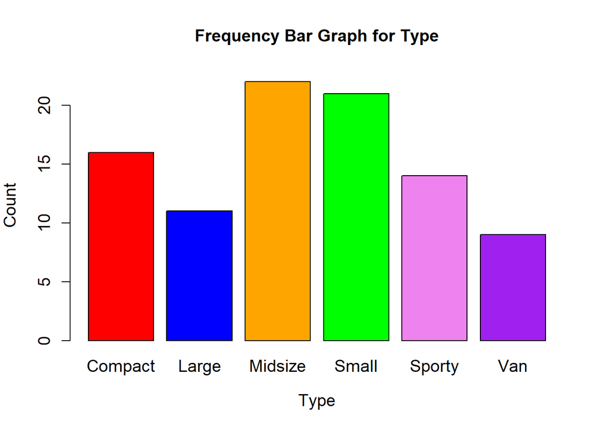

```r
type = c(Cars93$Type)
freq_table = table(type)
colors = c("red","blue","orange","green","violet","purple")
barplot(freq_table,
        main = "Frequency Bar Graph for Type",
        xlab = "Type",
        ylab = "Count",
        col = colors,
        border = "black",
        ylim = c(0, max(freq_table) + 1),
        names.arg = names(freq_table),
        cex.names = 1.2,
        cex.axis = 1.2,
        cex.lab = 1.2)
```

```r
print(freq_table)
```

```
## type
## Compact   Large Midsize   Small  Sporty     Van
##      16      11      22      21      14       9
```

- Your axes should be labeled and legible
- The bars should be of different colors
- The plot should include a title using the main argument
- The names, labels, and axes sizes (cex parameter) should be set to 1.2
3. Create a pie chart of the variable `Type`.

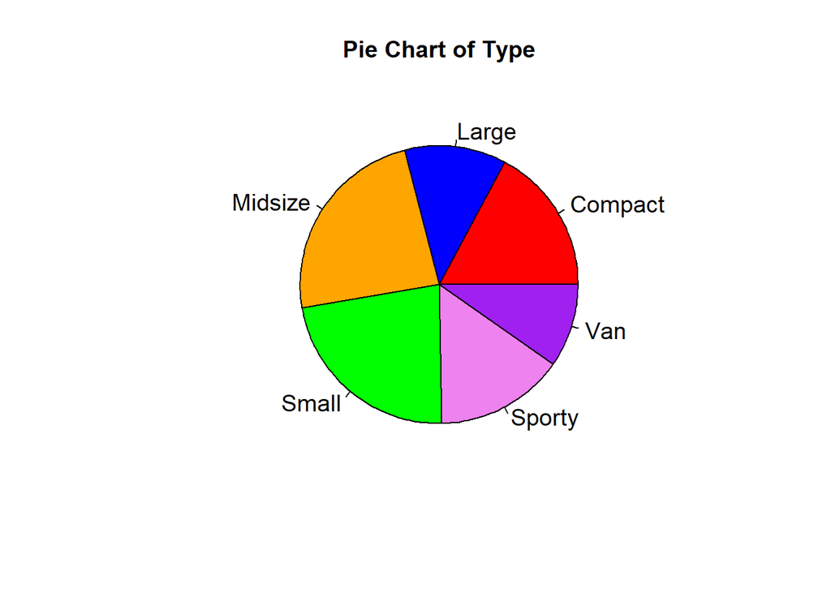

```r
type = c(Cars93$Type)
freq_table = table(type)
colors = c("red","blue","orange","green","violet","purple")
pie(freq_table,
        main = "Pie Chart of Type",
        col = colors,
        cex = 1.2)
```

```r
print(freq_table)
```

```
## type
## Compact   Large Midsize   Small  Sporty     Van
##      16      11      22      21      14       9
```

- The plot should include a title using the main argument.
- The names, labels, and axes sizes (cex parameter) should be set to 1.2
4. What is the mode of the variable `Type`? Comment.

Midsize is the mode because they are the highest on the frequency table at 22.